# Intro to DS - Logit Regression

Michael Womble

# HW Assignment - Logit Regression

We have the historic Titanic dataset to study here. The version presented has these variables:

- `survival`: Survival, 0 = No, 1 = Yes
- `pclass`: Ticket class, 1 = 1st, 2 = 2nd, 3 = 3rd
- `sex`: Gender / Sex
- `age`: Age in years
- `sibsp`: # of siblings / spouses on the Titanic
- `parch`: # of parents / children on the Titanic
- `ticket`: Ticket number (for superstitious ones)
- `fare`: Passenger fare
- `embarked`: Port of Embarkment C: Cherbourg, Q: Queenstown, S: Southampton

The questions listed here are the basic guidelines, not the only goal, in this homework. For example, after you load the dataframe, even though the question does not ask you to look at the structure of the dataframe, you most likely should. You are given less and less “specific to-dos” in the homework, as you are getting more familiar with the data analytic process. Calculate and figure out the necessary info needed in the analysis, even though the questions might not ask for them explicitly. When you look at your own work, you should find it convincing, answering the questions and technically sound.

## Titanic Tragedy Dataset

### Question 1

**Import the dataset into R**  
Import the dataset into R, and call it titanic_orig, and explore it little to get the overall picture of the dataset. Eventually we would like to see what affected survival in the tragedy.

```r
titanic_org<-data.frame(read.csv('Titanic.csv'))
```

### Question 2

**Age**  
One of the main factors we will try is Age. How many missing values are there for the variable `age`? If not too many, we should just clean those up and subset those out.

```r
summary(titanic_org)
str(titanic_org)
age_missing<-subset(titanic_org, is.na(age))
titanic_org<-na.omit(titanic_org)
summary(titanic_org)
```

[output not shown]

**Answer:** The age variable had 177 missing values. These were subsetted out and removed fromt the dataset.

### Question 3

**More clean up**  
While we are cleaning up the data, if we were to use sibsp and parch in our analysis, even though they are legitimately ratio level variables, we might not expect doubling the number of siblings necessarily double the effects on survival. For this reason, we should change these two variables to factor levels. Also change the other ones that you find imported as the wrong data type.

```r
str(titanic_org)
titanic_org$sibsp<-as.factor(titanic_org$sibsp)
titanic_org$parch<-as.factor(titanic_org$parch)
titanic_org$sex<-as.factor(titanic_org$sex)
titanic_org$embarked<-as.factor(titanic_org$embarked)
str(titanic_org)
```

**Answer:** I changed four variables to the fator data type. These variables are the sibsp, parch, sex, and embarked variables.

## Pre-logistic Regression

### Question 4

**Survival and age**  
Before using our newly learned technique with logistic regression, let’s go old school, and use some prior knowledge to try find an answer. Does the data support that `age` very much affects `survival`?

```r
age_survival_table<-xtabs(~ survived + age, data = titanic_org)
age_survival_table
```

```
##         age
## survived 0.42 0.67 0.75 0.83 0.92  1  2  3  4  5  6  7  8  9 10 11 12 13 14
##        0    0    0    0    0    0  2  7  1  3  0  1  2  2  6  2  3  0  0  3
##        1    1    1    2    2    1  5  3  5  7  4  2  1  2  2  0  1  1  2  3
##         age
## survived 14.5 15 16 17 18 19 20 20.5 21 22 23 23.5 24 24.5 25 26 27 28 28.5 29
##        0    1  1 11  7 17 16 12    1 19 16 10    1 15    1 17 12  7 18    2 12
##        1    0  4  6  6  9  9  3    0  5 11  5    0 15    0  6  6 11  7    0  8
##         age
## survived 30 30.5 31 32 32.5 33 34 34.5 35 36 36.5 37 38 39 40 40.5 41 42 43 44
##        0 15    2  9  9    1  9  9    1  7 11    1  5  6  9  7    2  4  7  4  6
##        1 10    0  8  9    1  6  6    0 11 11    0  1  5  5  6    0  2  6  1  3
##         age
## survived 45 45.5 46 47 48 49 50 51 52 53 54 55 55.5 56 57 58 59 60 61 62 63 64
##        0  7    2  3  8  3  2  5  5  3  0  5  1    1  2  2  2  2  2  3  2  0  2
##        1  5    0  0  1  6  4  5  2  3  1  3  1    0  2  0  3  0  2  0  2  2  0
##         age
## survived 65 66 70 70.5 71 74 80
##        0  3  1  2    1  2  1  0
##        1  0  0  0    0  0  0  1
```

```r
chisqr_age<-chisq.test(age_survival_table)
chisqr_age
```

```
##
##  Pearson's Chi-squared test
##
## data:  age_survival_table
## X-squared = 104, df = 87, p-value = 0.1
```

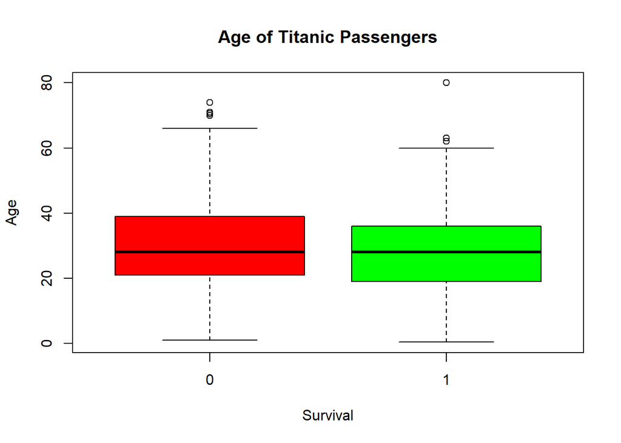

```r
library(ggplot2)

boxplot(titanic_org$age~titanic_org$survived,
        main='Age of Titanic Passengers',
        xlab = 'Survival',
        ylab = 'Age',
        col=c('Red','Green'))
```

```r
age_survival<-subset(titanic_org, survived==1)
age_dead<-subset(titanic_org, survived==0)
t.test(age_survival$age, mu=mean(age_dead$age), conf.level = 0.95)
```

[output not shown]

**Answer:** To test for variable dependency a contingency table comparing survival and age was made. The chi square test was then run on the table giving a p-value of 0.1 indicating the variables are independent of each other. However, the expected cell values for many of the cells was less than 5 meaning that this may be unreliable. To double check a boxplot was made comparing the age distributions of the passengers that survived and those that did not. There appears to be no difference between the two. To further confirm this the data was subsetted to form a survivor group and a dead group. A t-test comparing the age mean of the two subsets. This resulted in a p-value of 0.01 indicating that there is a difference between the means of these two groups which means there may be a dependency of survival on age.

### Question 5

**Survival and gender**  
Similarly, does the data support `sex` has an effect on `survival`?

```r
sex_survival_table<-xtabs( ~ survived + sex, data = titanic_org)
sex_survival_table
```

```
##         sex
## survived female male
##        0     64  360
##        1    197   93
```

```r
chisqr_sex<-chisq.test(sex_survival_table)
chisqr_sex
```

```
##
##  Pearson's Chi-squared test with Yates' continuity correction
##
## data:  sex_survival_table
## X-squared = 205, df = 1, p-value <2e-16
```

**Answer:** Making a contingency table and running a chi square test on it results in a p-value of < 2E-16 indicating a dependency of survival on sex.

### Question 6

**Survival and pclass**  
Another big question is, does the data support Ticket class `pclass` has an effect on `survival`?

```r
pclass_survival_table<-xtabs( ~ survived + pclass, data=titanic_org)
pclass_survival_table
```

```
##         pclass
## survived   1   2   3
##        0  64  90 270
##        1 122  83  85
```

```r
chisqr_pclass<-chisq.test(pclass_survival_table)
chisqr_pclass
```

```
##
##  Pearson's Chi-squared test
##
## data:  pclass_survival_table
## X-squared = 93, df = 2, p-value <2e-16
```

**Answer:** Making a contingency table and running a chi square test on it results in a p-value of < 2E-16 indicating a dependency of survival on passenger class.

## Logistic Regression

### Question 7

**Survival and age + pclass**  
Now let us build a logit model with age+pclass as predictors, and analyze the results. Remember to do all the model evaluation steps. Is the model a good one?

```r
loadPkg("regclass")
loadPkg("ResourceSelection")
loadPkg("pROC")

survival_logit_model1<-glm(survived ~ age + pclass, data=titanic_org, family = 'binomial')
summary(survival_logit_model1)
```

```
##
## Call:
## glm(formula = survived ~ age + pclass, family = "binomial", data = titanic_org)
##
## Deviance Residuals:
##    Min      1Q  Median      3Q     Max
## -2.171  -0.855  -0.614   1.013   2.388
##
## Coefficients:
##             Estimate Std. Error z value Pr(>|z|)
## (Intercept)  3.58545    0.40676    8.81  < 2e-16 ***
## age         -0.04201    0.00672   -6.25  4.2e-10 ***
## pclass      -1.24385    0.11906  -10.45  < 2e-16 ***
## ---
## Signif. codes:  0 '***' 0.001 '**' 0.01 '*' 0.05 '.' 0.1 ' ' 1
##
## (Dispersion parameter for binomial family taken to be 1)
##
##     Null deviance: 964.52  on 713  degrees of freedom
## Residual deviance: 827.43  on 711  degrees of freedom
## AIC: 833.4
##
## Number of Fisher Scoring iterations: 4
```

```r
prob1=predict(survival_logit_model1, type = "response" )
titanic_org$prob1=prob1
h1 <- roc(survived~prob1, data=titanic_org)
auc(h1) # area-under-curve prefer 0.8 or higher.
```

```
## Area under the curve: 0.744
```

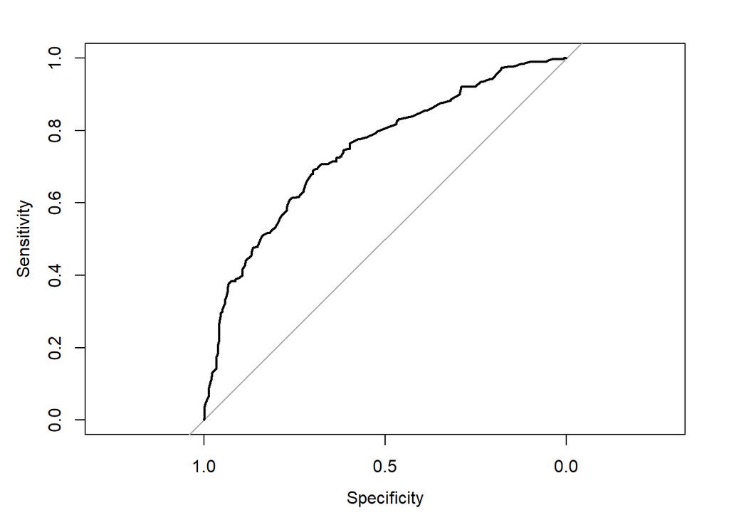

```r
plot(h1)
```

### Question 8

**More features**  
Can we improve the model? Let us also throw in `sex` as a predictor. How’s the model now?

```r
survival_logit_model2<-glm(survived ~ age + pclass+ sex, data=titanic_org, family='binomial')
summary(survival_logit_model2)
```

```
##
## Call:
## glm(formula = survived ~ age + pclass + sex, family = "binomial",
##     data = titanic_org)
##
## Deviance Residuals:
##    Min      1Q  Median      3Q     Max
## -2.727  -0.680  -0.395   0.648   2.467
##
## Coefficients:
##             Estimate Std. Error z value Pr(>|z|)
## (Intercept)  5.05601    0.50213   10.07  < 2e-16 ***
## age         -0.03693    0.00763   -4.84  1.3e-06 ***
## pclass      -1.28855    0.13926   -9.25  < 2e-16 ***
## sexmale     -2.52213    0.20728  -12.17  < 2e-16 ***
## ---
## Signif. codes:  0 '***' 0.001 '**' 0.01 '*' 0.05 '.' 0.1 ' ' 1
##
## (Dispersion parameter for binomial family taken to be 1)
##
##     Null deviance: 964.52  on 713  degrees of freedom
## Residual deviance: 647.29  on 710  degrees of freedom
## AIC: 655.3
##
## Number of Fisher Scoring iterations: 5
```

```r
prob2=predict(survival_logit_model2, type = "response" )
titanic_org$prob1=prob2
h2 <- roc(survived~prob2, data=titanic_org)
auc(h2) # area-under-curve prefer 0.8 or higher.
```

```
## Area under the curve: 0.852
```

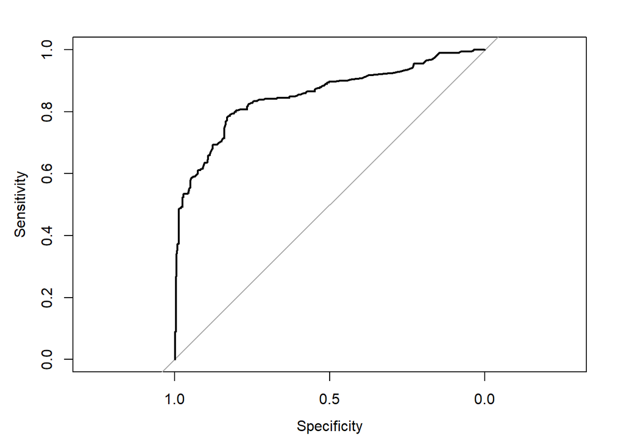

```r
plot(h2)
```

### Question 9

**Sample Predictions**  
According to the last model, what is the chance of survival for a female, age 10, second class passenger? And a male, age 20, first class passenger?

```r
female_10<-data.frame(age=10, pclass=2, sex='female')
male_20<-data.frame(age=20, pclass=1, sex='male')

predict(survival_logit_model2, newdata = female_10, type='response')
predict(survival_logit_model2, newdata = male_20, type='response')
```

[output not shown]

## Interpretation

### Question 10

*Summary*  
With all the results you obtained above, how would you present a high-level summary of the findings? Are the results surprising or expected? You might need to dig a little deeper than just the numbers, the test results/p-values, and the model statistics. This is a question about who we are, … in the face of death.